# Questionnaire Report for Blue grenadier

(MERA version 4.1.1)

Adrian Hordyk (a.hordyk@oceans.ubc.ca)

2019-04-23

# 1 About this document

This is a prototype of an automatic report that documents how the user specified the operating model and their various justifications.

# 2 Introduction

This questionnaire was populated using the information from [Castillo-Jordán and Tuck (2018)](https://www.dropbox.com/s/hk4hgg1az90ysef/SERAG%20Sept%202018_Agenda%20item%206%20-%20BG_Sept_2018_v5.pdf?dl=0) - referred to as ‘the assessment report’ throughout the questionnaire.

Blue grenadier are caught by demersal trawling in south-eastern Australia.

More details will be added to this section at a later date.

1. Describe the history and current status of the fishery, including fleets, sectors, vessel types and practices/gear by vessel type, landing ports, economics/markets, whether targeted/bycatch, other stocks caught in the fishery.
2. Describe the stock’s ecosystem functions, dependencies, and habitat types.
3. Provide all relevant reference materials, such as assessments, research, and other analysis.

Castillo-Jordán, C. and Tuck, G.N. (2018). Blue grenadier (*Macruronus novaezelandiae*) stock assessment based on data up to 2017 – development of a preliminary base case. Technical paper presented to the SERAG, 19-21 September 2018, Hobart, Australia

# 3 Fishery Characteristics

## 3.1 Longevity

| Answered |
| --- |
| Very short-lived (5 < maximum age < 7) |
| Short-lived (7 < maximum age < 10) |
| Moderate life span (10 < maximum age < 20) |
| Moderately long-lived (20 < maximum age < 40) |
| Long-lived (40 < maximum age < 80) |
| Very long-lived (80 < maximum age < 160) |

| Justification |
| --- |
| The assessment reports a maximum age of about 25 years and an MLE for natural mortality of 0.173. |

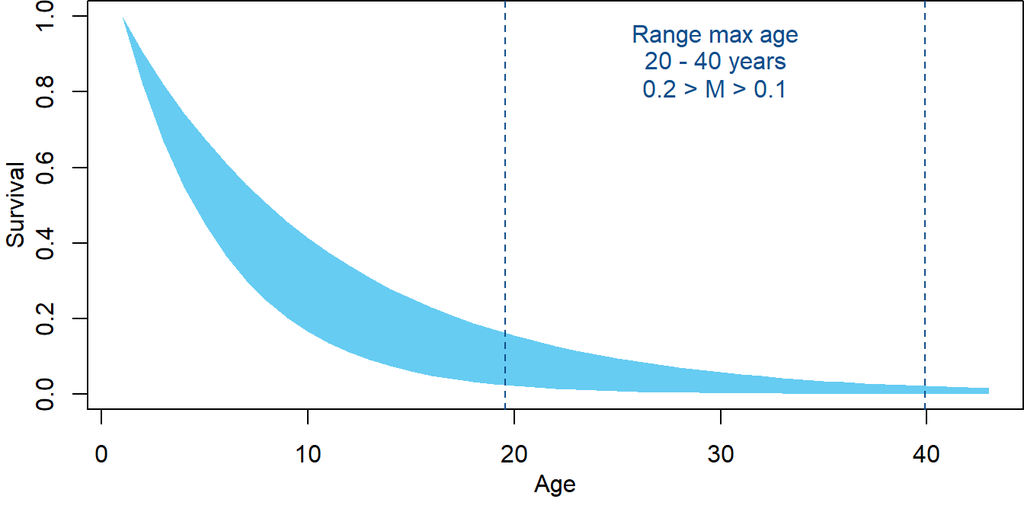

## 3.2 Stock depletion

| Answered |
| --- |
| Crashed (D < 0.05) |
| Very depleted (0.05 < D < 0.1) |
| Depleted (0.1 < D < 0.15) |
| Moderately depleted (0.15 < D < 0.3) |
| Healthy (0.3 < D < 0.5) |
| Underexploited (0.5 < D) |

[output not shown]

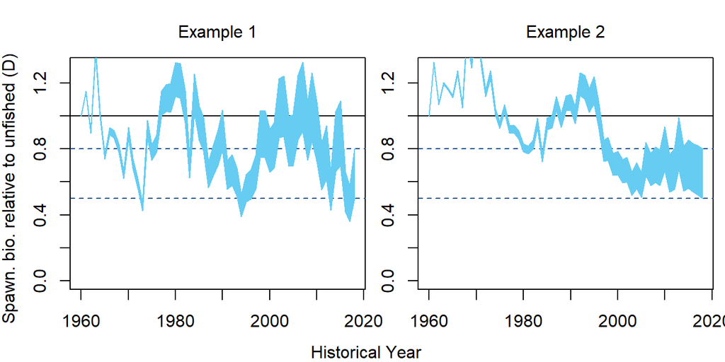

## 3.3 Resilence

| Answered |
| --- |
| Not resilient (steepness < 0.3) |
| Low resilience (0.3 < steepness < 0.5) |
| Moderate resilence (0.5 < steepness < 0.7) |
| Resilient (0.7 < steepness < 0.9) |
| Very Resilient (0.9 < steepness) |

[output not shown]

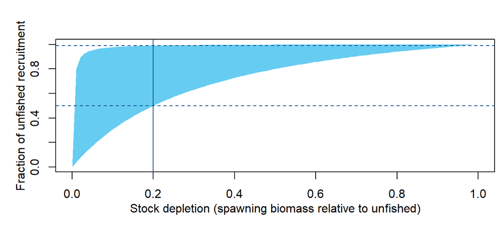

## 3.4 Historical effort pattern

| Answered |
| --- |
| Stable |
| Two-phase |
| Boom-bust |
| Gradual increases |
| Stable, recent increases |
| Stable, recent declines |

Justification

Table 2 in the stock assessment report shows the landed and discarded catches by year from 1979 to 2018, and reports the CPUE from 1986 to 2017. An index of historical fishing effort was generated by dividing the reported total catch by the CPUE.  
The ‘Boom-bust’ effort pattern was used to generate a historical effort pattern that matched the reported trend. However, it was not possible to fully capture the fluctuations in fishing effort that occurred in the later 1990 and around 2011.  
See [here](https://www.dropbox.com/s/fiymr9xvdyanyup/Effort.PNG) for data used to create the effort trajectory.

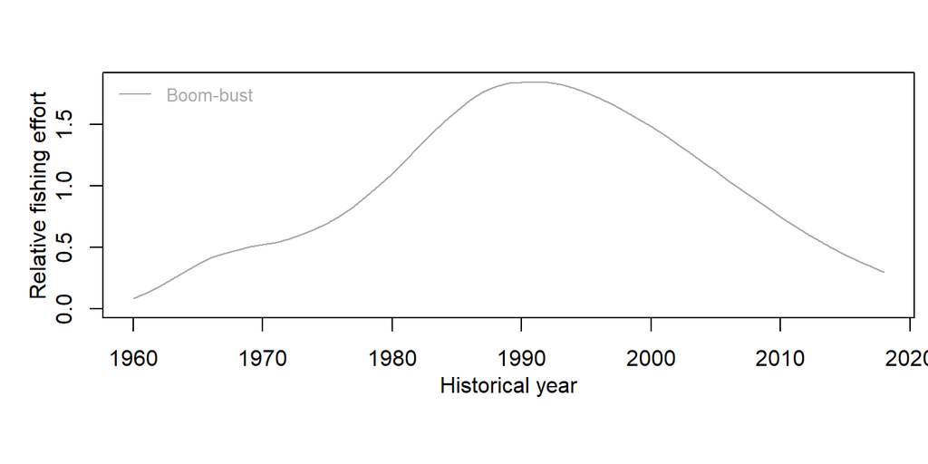

## 3.5 Inter-annual variability in historical effort

| Answered |
| --- |
| Not variable (less than 20% inter-annual change (IAC)) |
| Variable (maximum IAC between 20% to 50%) |
| Highly variable (maximum IAC between 50% and 100%) |

[output not shown]

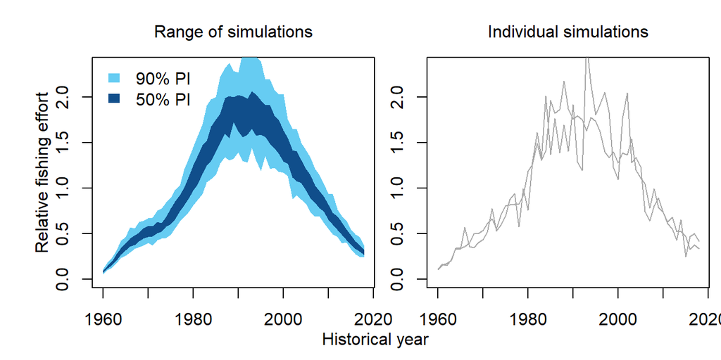

## 3.6 Historical fishing efficiency changes

| Answered |
| --- |
| Declining by 2-3% pa (halves every 25-35 years) |
| Declining by 1-2% pa (halves every 35-70 years) |
| Stable -1% to 1% pa (may halve/double every 70 years) |
| Increasing by 1-2% pa (doubles every 35-70 years) |
| Increasing by 2-3% pa (doubles every 25-35 years) |

Justification

The stock assessment document does not report any information on changes in historical fishing efficiency. It seems unlikely that fishing efficiency would have decreased significantly over the historical period of the fishery. An increase in fishing efficiency is perhaps more likely, as fishers developed an increased knowledge of the fishery over time, as well as the introduction of new technologies in this period. However, this increase in efficiency is difficult to quantify in the absence of more information.  
The changes in historical fishing efficiency were set to cover a range from ‘Stable’ to slightly increasing fishing efficiency.

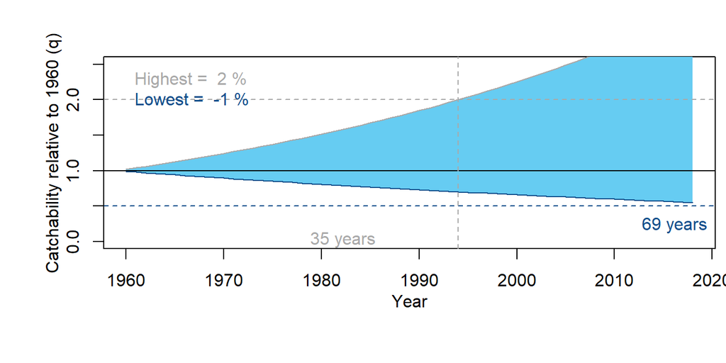

## 3.7 Future fishing efficiency changes

| Answered |
| --- |
| Declining by 2-3% pa (halves every 25-35 years) |
| Declining by 1-2% pa (halves every 35-70 years) |
| Stable -1% to 1% pa (may halve/double every 70 years) |
| Increasing by 1-2% pa (doubles every 35-70 years) |
| Increasing by 2-3% pa (doubles every 25-35 years) |

| Justification |
| --- |
| No information in likely future changes in fishing efficiency is available. The same range was used as for changes in historical fishing efficiency described in the previous question. |

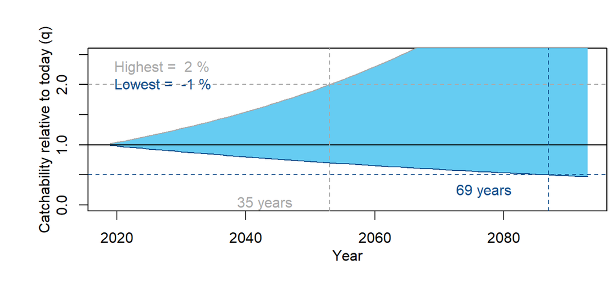

## 3.8 Length at maturity

| Answered |
| --- |
| Very small (0.4 < LM < 0.5) |
| Small (0.5 < LM < 0.6) |
| Moderate (0.6 < LM < 0.7) |
| Moderate to large (0.7 < LM < 0.8) |
| Large (0.8 < LM < 0.9) |

| Justification |
| --- |
| The assessment reports a mean length of maturity for males and females that is about 64% of the asymptotic length. |

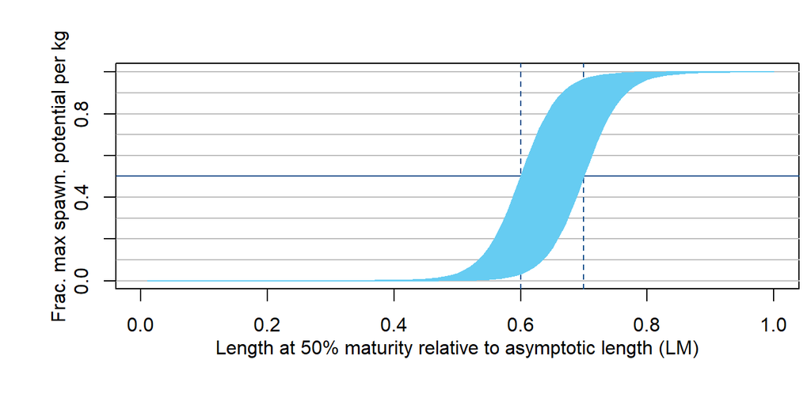

## 3.9 Selectivity of small fish

| Answered |
| --- |
| Very small (0.1 < S < 0.2) |
| Small (0.2 < S < 0.4) |
| Half asymptotic length (0.4 < S < 0.6) |
| Large (0.6 < S < 0.8) |
| Very large (0.8 < S < 0.9) |

[output not shown]

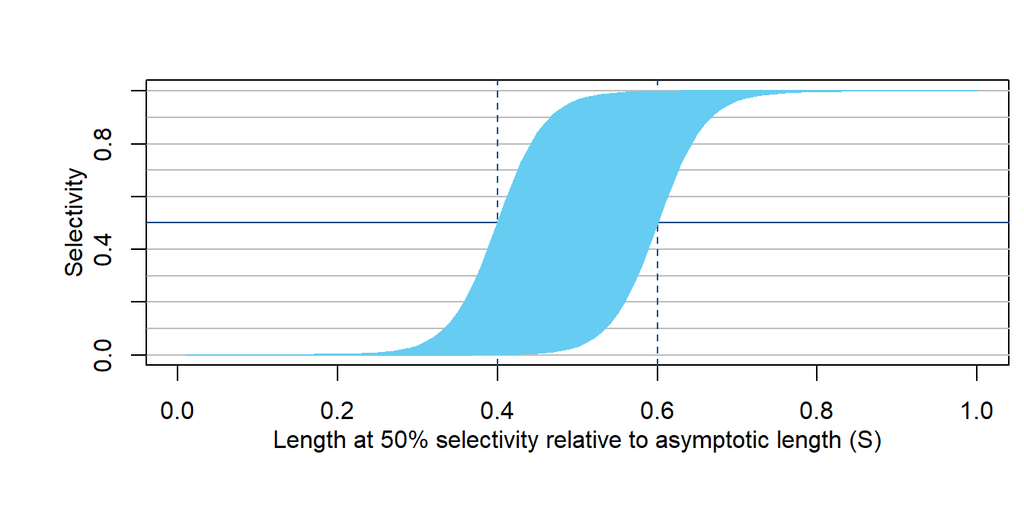

## 3.10 Selectivity of large fish

| Answered |
| --- |
| Asymptotic selectivity (SL = 1) |
| Declining selectivity with length (0.75 < SL < 1) |
| Dome-shaped selectivity (0.25 < SL < 0.75) |
| Strong dome-shaped selectivity (SL < 0.25) |

[output not shown]

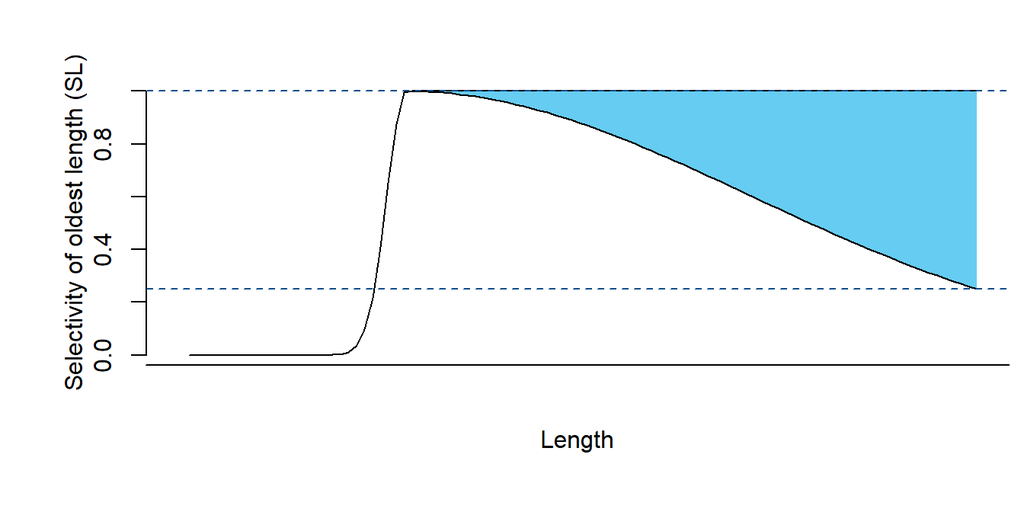

## 3.11 Discard rate

| Answered |
| --- |
| Low (DR < 1%) |
| Low - moderate (1% < DR < 10%) |
| Moderate (10% < DR < 30%) |
| Moderate - high (30% < DR < 50%) |
| High (50% < DR < 70%) |

[output not shown]

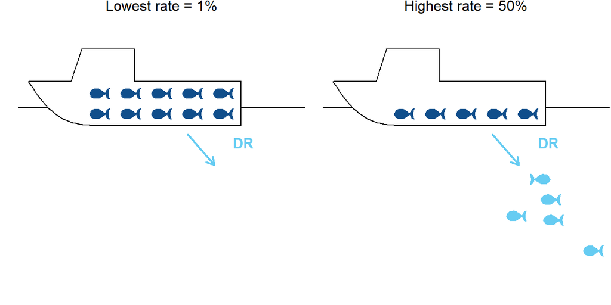

## 3.12 Post-release mortality rate

| Answered |
| --- |
| Low (PRM < 5%) |
| Low - moderate (5% < PRM < 25%) |
| Moderate (25% < PRM < 50%) |
| Moderate - high (50% < PRM < 75%) |
| High (75% < PRM < 95%) |
| Almost all die (95% < PRM < 100%) |

| Justification |
| --- |
| The species are caught using trawl gear and it is unlikely that survival of discarded fish is high. The assessment assumes a 100% mortality rate of discarded fish. |

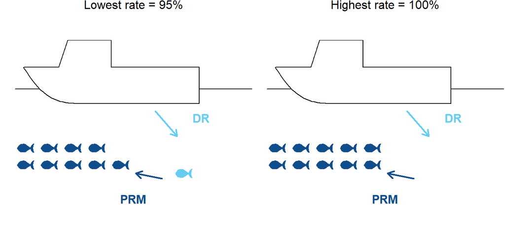

## 3.13 Recruitment variability

| Answered |
| --- |
| Very low (less than 10% inter-annual changes (IAC)) |
| Low (max IAC of between 20% and 60%) |
| Moderate (max IAC of between 60% and 120%) |
| High (max IAC of between 120% and 180%) |
| Very high (max IAC greater than 180%) |

[output not shown]

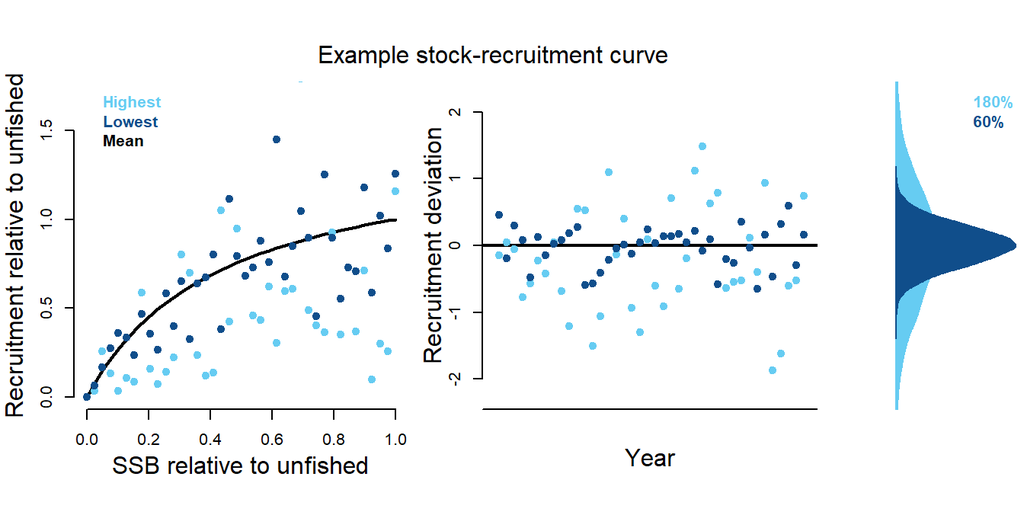

## 3.14 Size of an existing MPA

| Answered |
| --- |
| None |
| Small (A < 5%) |
| Small-moderate (5% < A < 10%) |
| Moderate (10% < A < 20%) |
| Large (20% < A < 30%) |
| Very large (30% < A < 40%) |
| Huge (40% < A < 50%) |

| Justification |
| --- |
| The stock assessment does not mention any existing MPA or spatial management that is in place for this fishery. |

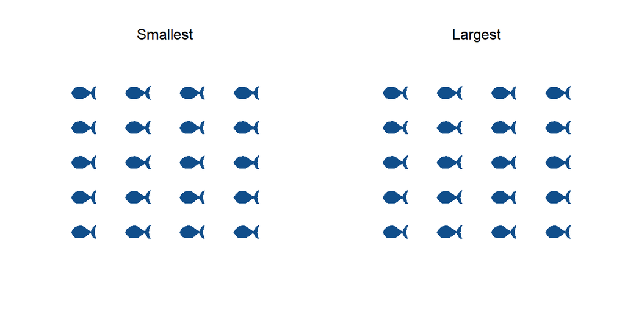

## 3.15 Spatial mixing (movement) in/out of existing MPA

| Answered |
| --- |
| Very low (P < 1%) |
| Low (1% < P < 5%) |
| Moderate (5% < P < 10%) |
| High (10% < P < 20%) |
| Fully mixed |

| Justification |
| --- |
| Given no spatial structure in this fishery, it was assumed that the stock was fully mixed. |

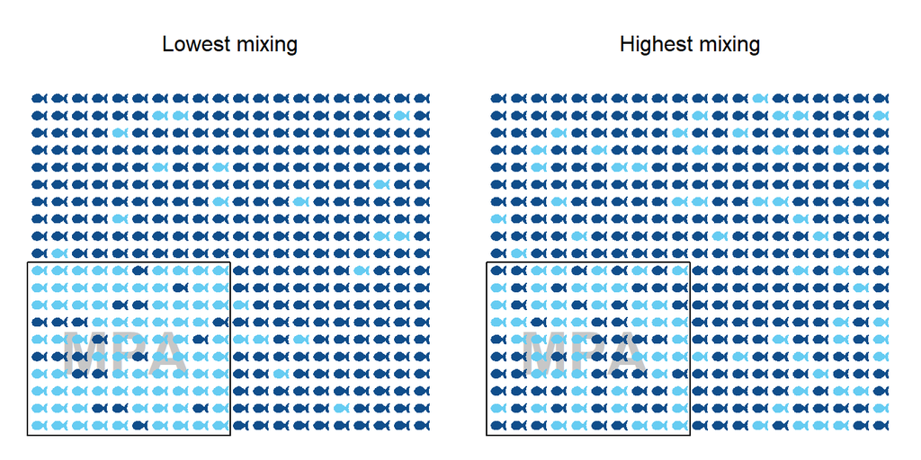

## 3.16 Size of a future potential MPA

| Answered |
| --- |
| None |
| Small (A < 5%) |
| Small-moderate (5% < A < 10%) |
| Moderate (10% < A < 20%) |
| Large (20% < A < 30%) |
| Very large (30% < A < 40%) |
| Huge (40% < A < 50%) |

| Justification |
| --- |
| No future MPAs were assumed. However, the full range of options was chosen to explore the potential of spatial closures for managing this stock in the future. |

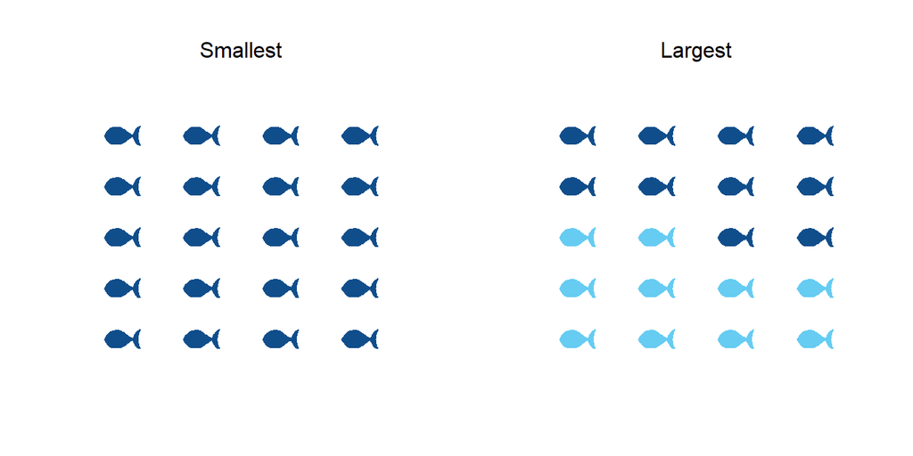

## 3.17 Spatial mixing (movement) in/out of future potential MPA

| Answered |
| --- |
| Very low (P < 1%) |
| Low (1% < P < 5%) |
| Moderate (5% < P < 10%) |
| High (10% < P < 20%) |
| Fully mixed |

| Justification |
| --- |
| No information is available on the movement rates for this species. The full range of spatial mixing options was chosen to reflect this uncertainty. |

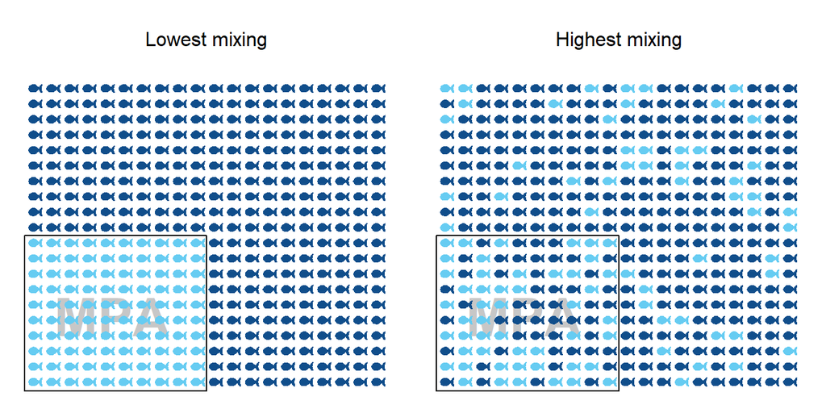

## 3.18 Initial stock depletion

| Answered |
| --- |
| Very low (0.1 < D1 < 0.15) |
| Low (0.15 < D1 < 0.3) |
| Moderate (0.3 < D < 0.5) |
| High (0.5 < D1) |
| Asymptotic unfished levels (D1 = 1) |

| Justification |
| --- |
| The assessment assumed that the stock was at an unfished equilibrium in 1960. |

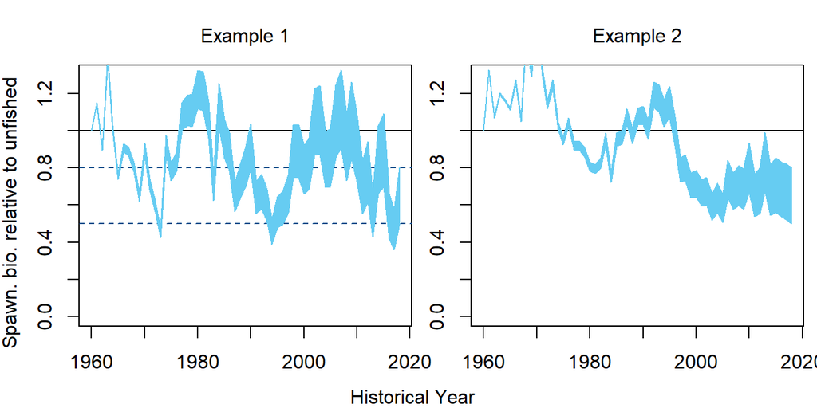

# 4 Management Characteristics

## 4.1 Types of fishery management that are possible

| Answered |
| --- |
| TAC (Total Allowable Catch): a catch limit |
| TAE (Total Allowable Effort): an effort limit |
| Size limit |
| Time-area closures (a marine reserve) |

Justification

1. Describe what, if any, current management measures are used to constrain catch/effort.  
Blue grenadier are managed with a total allowable catch (TAC).  
All management options are included here to explore the potential of these approaches for managing this fishery.  
2. Describe historical management measures, if any.  
3. Describe main strengths and weaknesses of current monitoring and enforcement capacity.  
4. Describe and reference any legal/policy requirements for management, monitoring and enforcement.

## 4.2 TAC offset: consistent overages/underages

| Answered |
| --- |
| Large underages (40% - 70% of recommended) |
| Underages (70% - 90% of recommended) |
| Slight underages (90% - 100% of recommended) |
| Taken exactly (95% - 105% of recommended) |
| Slight overages (100% - 110% of recommended) |
| Overages (110% - 150% of recommended) |
| Large overages (150% - 200% of recommended) |

[output not shown]

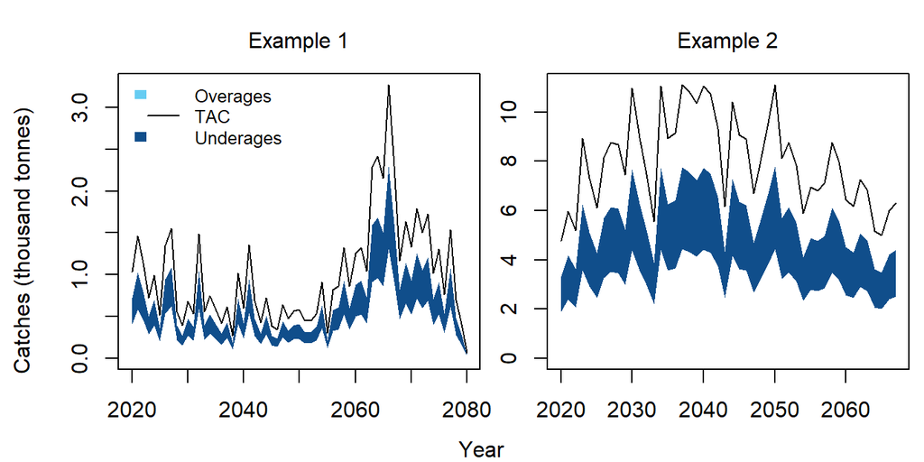

## 4.3 TAC implementation variability

| Answered |
| --- |
| Constant (V < 1%) |
| Not variable (1% < V < 5%) |
| Low variability (5% < V < 10%) |
| Variable (10% < V < 20%) |
| Highly variable (20% < V < 40%) |

| Justification |
| --- |
| The fraction of the TAC that was caught each year was quite variable, with a CV of 37% and an average inter-annual variability of 25%. |

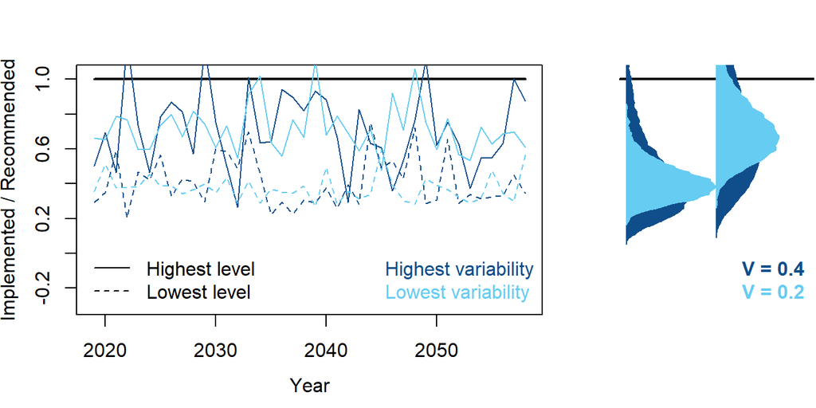

## 4.4 TAE offset: consistent overages/underages

| Answered |
| --- |
| Large underages (40% - 70% of recommended) |
| Underages (70% - 90% of recommended) |
| Slight underages (90% - 100% of recommended) |
| Taken exactly (95% - 105% of recommended) |
| Slight overages (100% - 110% of recommended) |
| Overages (110% - 150% of recommended) |
| Large overages (150% - 200% of recommended) |

[output not shown]

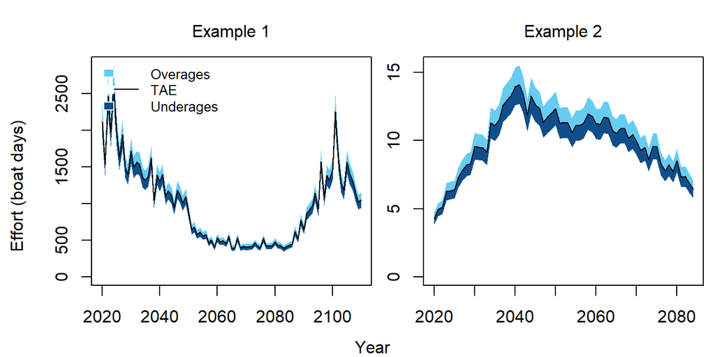

## 4.5 TAE implementation variability

| Answered |
| --- |
| Constant (V < 1%) |
| Not variable (1% < V < 5%) |
| Low variability (5% < V < 10%) |
| Variable (10% < V < 20%) |
| Highly variable (20% < V < 40%) |

| Justification |
| --- |
| No information is available on the expected variability in a TAE implementation. A wide range was selected here to reflect the uncertainty with this management approach. |

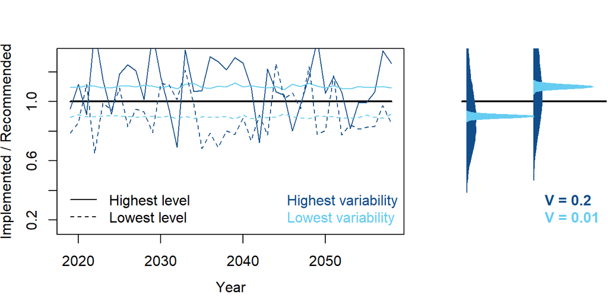

## 4.6 Size limit offset: consistent overages/underages

| Answered |
| --- |
| Much smaller (40% - 70% of recommended) |
| Smaller (70% - 90% of recommended) |
| Slightly smaller (90% - 100% of recommended) |
| Taken exactly (95% - 105% of recommended) |
| Slightly larger (100% - 110% of recommended) |
| Larger (110% - 150% of recommended) |
| Much larger (150% - 200% of recommended) |

Justification

Blue grenadier are caught in a trawl fishery. A size limit may not a practical management option for this fishery due to the difficulty in controlling selectivity pattern and the high discard mortality. The implementation of any potential size regulation would depend on the minimum legal size that was chosen.  
It is unlikely that the fishery would only catch fish well above the size limit. On the other hand, the catch of fish below the minimum legal size is possible due to the non-selective nature of trawl fishing. A wide range was chosen to reflect this uncertainty.

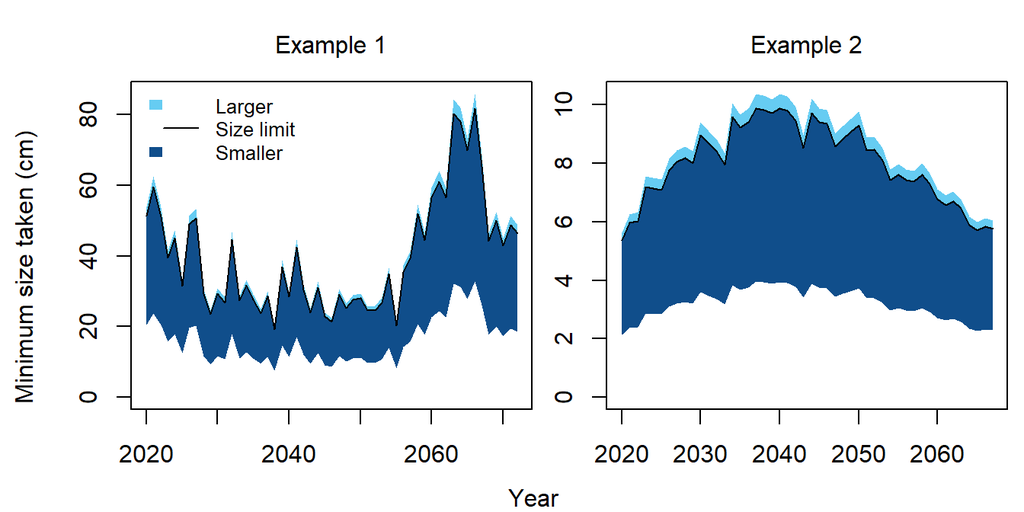

## 4.7 Size limit implementation variability

| Answered |
| --- |
| Constant (V < 1%) |
| Not variable (1% < V < 5%) |
| Low variability (5% < V < 10%) |
| Variable (10% < V < 20%) |
| Highly variable (20% < V < 40%) |

[output not shown]

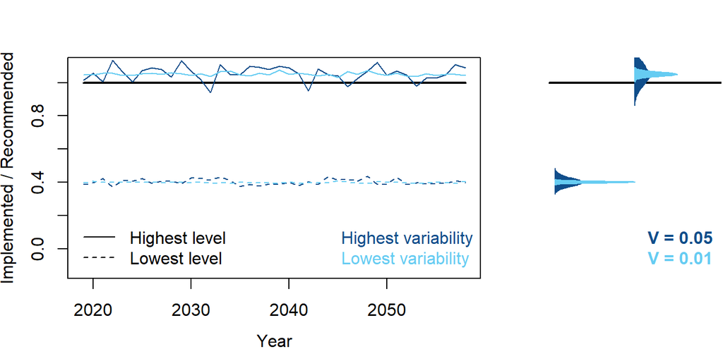

# 5 Data Characteristics

## 5.1 Available data types

| Answered |
| --- |
| Historical annual catches (from unfished) |
| Recent annual catches (at least 5 recent years) |
| Historical relative abundance index (from unfished) |
| Recent relative abundance index (at least 5 recent years) |
| Fishing effort |
| Size composition (length samples) |
| Age composition (age samples) |
| Growth (growth parameters) |
| Absolute biomass survey |

Justification

1. Provide the time series (specify years, if possible) that exist for catch, effort, and CPUE/abundance indices.  
All data types appear to be available for this fishery. Catch records exist from 1979, not quite the beginning of the history of the fishery (assumed to be unfished in 1960).  
2. Describe how these data collected (e.g., log books, dealer reporting, observers).  
3. Describe what types of sampling programs and methodologies exist for data collection, including the time-series of available sampling data and quality.  
4. Describe all sources of uncertainty in the status, biology, life history and data sources of the fishery. Include links to documentation, reports.

## 5.2 Catch reporting bias

| Answered |
| --- |
| Strong under-reporting (30% - 50%) |
| Under-reporting (10% - 30%) |
| Slight under-reporting (less than 10%) |
| Reported accurately (+/- 5%) |
| Slight over-reporting (less than 10%) |

| Justification |
| --- |
| The assessment report does not make explicit mention of catch reporting bias. However, it is assumed that the catches are reported relatively accurately. |

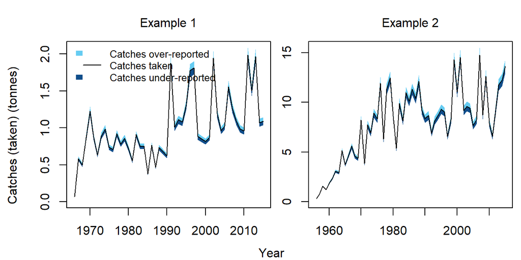

## 5.3 Hyperstability in indices

| Answered |
| --- |
| Strong hyperdepletion (2 < Beta < 3) |
| Hyperdepletion (1.25 < Beta < 2) |
| Proportional (0.8 < Beta < 1.25) |
| Hyperstability (0.5 < Beta < 0.8) |
| Strong hyperstability (0.33 < Beta < 0.5) |

[output not shown]

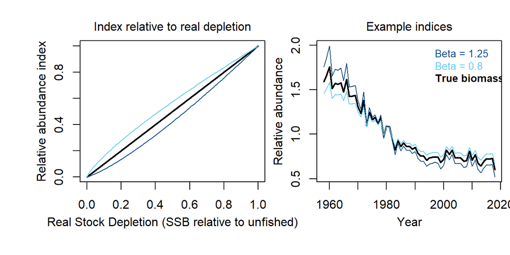

| Answered |
| --- |
| Perfect |
| Good (accurate and precise) |
| Data moderate (some what inaccurate and imprecise) |
| Data poor (inaccurate and imprecise) |

[output not shown]

# 6 Version Notes

The package is subject to ongoing testing. If you find a bug or a problem please send a report to t.carruthers@oceans.ubc.ca so that it can be fixed!

User-2019-04-23-09:46:40

copyright (c) NRDC 2019